# Titanic_Analyst

7

1

```
import numpy as np
```

2

```
import pandas as pd
```

3

```
import matplotlib.pyplot as plt
```

4

```
import seaborn as sns
```

5

```
from pylab import *
```

6

```
mpl.rcParams['font.sans-serif'] = ['SimHei'] #用来正常显示中文标签
```

7

```
plt.rcParams['axes.unicode_minus'] = False  #用来正常显示负号
```

2

1

```
ship = sns.load_dataset("titanic")
```

2

```
ship.head()
```

|  | survived | pclass | sex | age | sibsp | parch | fare | embarked | class | who | adult_male | deck | embark_town | alive | alone |
| --- | --- | --- | --- | --- | --- | --- | --- | --- | --- | --- | --- | --- | --- | --- | --- |
| 0 | 0 | 3 | male | 22.0 | 1 | 0 | 7.2500 | S | Third | man | True | NaN | Southampton | no | False |
| 1 | 1 | 1 | female | 38.0 | 1 | 0 | 71.2833 | C | First | woman | False | C | Cherbourg | yes | False |
| 2 | 1 | 3 | female | 26.0 | 0 | 0 | 7.9250 | S | Third | woman | False | NaN | Southampton | yes | True |
| 3 | 1 | 1 | female | 35.0 | 1 | 0 | 53.1000 | S | First | woman | False | C | Southampton | yes | False |
| 4 | 0 | 3 | male | 35.0 | 0 | 0 | 8.0500 | S | Third | man | True | NaN | Southampton | no | True |

21

1

```
#### 数据说明
```

2

3

```
survived：是否存活，0代表死亡，1代表幸存，与alive重复，保留survived列；
```

4

5

```
pclass：表示客舱等级，1级最高，反映乘船人身份和地位，是class的数值化表示，保留pclass列；
```

6

7

```
fare：船票的费用，同一个pclass里也可能有不同的费用，保留；
```

8

9

```
sex：乘客的性别，who、adult_male表示信息一致，保留sex列；
```

10

11

```
age：乘客年龄，保留；
```

12

13

```
sibsp：同代亲属数量， 保留；
```

14

15

```
parch：非同代亲属，保留；
```

16

17

[output not shown]

18

19

```
deck：乘客的舱位,保留；
```

20

21

```
alone：是否独自一人，保留；
```

#### 数据说明

survived：是否存活，0代表死亡，1代表幸存，与alive重复，保留survived列；

pclass：表示客舱等级，1级最高，反映乘船人身份和地位，是class的数值化表示，保留pclass列；

fare：船票的费用，同一个pclass里也可能有不同的费用，保留；

sex：乘客的性别，who、adult_male表示信息一致，保留sex列；

age：乘客年龄，保留；

sibsp：同代亲属数量， 保留；

parch：非同代亲属，保留；

deck：乘客的舱位,保留；

alone：是否独自一人，保留；

6

1

```
#删除上述列，并将性别转化成0-1变量，male为1，female为0
```

2

```
ship = ship.drop(['alive', 'class', 'who', 'adult_male', 'embarked'], axis=1)
```

3

```
ship.loc[ship.sex=='male', 'sex'] = 1
```

4

```
ship.loc[ship.sex=='female', 'sex'] = 0
```

5

```
ship.info()
```

6

```
ship.shape
```

```
<class 'pandas.core.frame.DataFrame'>
RangeIndex: 891 entries, 0 to 890
Data columns (total 10 columns):
survived       891 non-null int64
pclass         891 non-null int64
sex            891 non-null int64
age            714 non-null float64
sibsp          891 non-null int64
parch          891 non-null int64
fare           891 non-null float64
deck           203 non-null category
embark_town    889 non-null object
alone          891 non-null bool
dtypes: bool(1), category(1), float64(2), int64(5), object(1)
memory usage: 57.9+ KB
```

```
(891, 10)
```

5

1

```
数据总量为891条，具有10个特征;
```

2

3

```
age缺失177条数据，考虑到age可能会影响救人时的决策，决定保留age列，使用填充的方法补全数据；
```

4

5

[output not shown]

数据总量为891条，具有10个特征;

age缺失177条数据，考虑到age可能会影响救人时的决策，决定保留age列，使用填充的方法补全数据；

4

1

```
#删除deck
```

2

```
ship = ship.drop(['deck'], axis=1)
```

3

[output not shown]

4

```
ship['age'] = ship['age'].fillna(ship['age'].median())
```

2

1

```
#数据量化特征描述统计
```

2

```
ship.describe()
```

|  | survived | pclass | sex | age | sibsp | parch | fare |
| --- | --- | --- | --- | --- | --- | --- | --- |
| count | 891.000000 | 891.000000 | 891.000000 | 891.000000 | 891.000000 | 891.000000 | 891.000000 |
| mean | 0.383838 | 2.308642 | 0.647587 | 29.361582 | 0.523008 | 0.381594 | 32.204208 |
| std | 0.486592 | 0.836071 | 0.477990 | 13.019697 | 1.102743 | 0.806057 | 49.693429 |
| min | 0.000000 | 1.000000 | 0.000000 | 0.420000 | 0.000000 | 0.000000 | 0.000000 |
| 25% | 0.000000 | 2.000000 | 0.000000 | 22.000000 | 0.000000 | 0.000000 | 7.910400 |
| 50% | 0.000000 | 3.000000 | 1.000000 | 28.000000 | 0.000000 | 0.000000 | 14.454200 |
| 75% | 1.000000 | 3.000000 | 1.000000 | 35.000000 | 1.000000 | 0.000000 | 31.000000 |
| max | 1.000000 | 3.000000 | 1.000000 | 80.000000 | 8.000000 | 6.000000 | 512.329200 |

1

1

```
### 描述性统计
```

### 描述性统计

5

1

```
#### 一维特征可视化
```

2

3

```
1、因变量**survived**幸存与死亡比例，得到整体的情况；
```

4

5

```
2、特征内部的结构与问题的研究高度相关，具有泛化特征更高层的表达能力，如**age**的结构反映了船上人们的年龄分布，**fare**可反映船上人的经济实力分布，从经验来看，以上二者均对人面对危机时做出的决策有重要影响；而**sex**与**pclass**与前者不同的是，**pclass**与**sex**比例往往是先验因素决定的，因此单独分析“三个船舱人员比例”和“穿上性别总体比例”是没有意义的，只有结合其他变量，如存活率时才有意义。
```

#### 一维特征可视化

1、因变量**survived**幸存与死亡比例，得到整体的情况；

2、特征内部的结构与问题的研究高度相关，具有泛化特征更高层的表达能力，如**age**的结构反映了船上人们的年龄分布，**fare**可反映船上人的经济实力分布，从经验来看，以上二者均对人面对危机时做出的决策有重要影响；而**sex**与**pclass**与前者不同的是，**pclass**与**sex**比例往往是先验因素决定的，因此单独分析“三个船舱人员比例”和“穿上性别总体比例”是没有意义的，只有结合其他变量，如存活率时才有意义。

1

1

```
#整体生存情况
```

2

```
survived = ship['survived'].value_counts()
```

3

```
survived
```

```
0    549
1    342
Name: survived, dtype: int64
```

1

1

```
#只有342个人存活
```

2

```
#计算生存比例
```

3

```
survived_perc = survived/survived.sum()
```

4

```
survived_perc
```

```
0    0.616162
1    0.383838
Name: survived, dtype: float64
```

1

1

```
#绘制饼图
```

2

```
fig = plt.figure(figsize=(5, 5))#绘制画布，第一个位置是长度，第二个位置是宽度
```

3

```
label = ['died', 'survived']
```

4

```
explode = 0.05, 0.05
```

5

6

```
ax1 = fig.add_subplot(1, 1, 1)#添加子图对象，子图为ax1
```

7

```
ax1.pie(survived_perc, labels=label, startangle=90, explode=explode, shadow=True, autopct='%3.2f%%',
```

8

```
       colors=sns.color_palette("Set3", 10))
```

[output not shown]

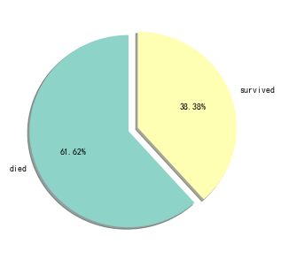

1

1

```
从图中可以看出，船上891个人中，只有342个人存活，死亡率高达61.62%
```

从图中可以看出，船上891个人中，只有342个人存活，死亡率高达61.62%

11

1

```
fig = plt.figure(figsize=(12, 14))
```

2

3

```
ax = fig.add_subplot(2, 1, 1)
```

4

```
ax = sns.distplot(ship['age'])
```

5

```
ax.set_xlabel('年龄', fontsize=16)
```

6

```
ax.set_title('年龄密度分布', fontsize=16)
```

7

8

```
ax = fig.add_subplot(2, 1, 2)
```

9

```
ax = sns.distplot(ship['fare'], color='r', rug=True)
```

10

```
ax.set_xlabel('费用', fontsize=16)
```

11

```
ax.set_title('消费密度分布', fontsize=16)
```

```
Text(0.5,1,'消费密度分布')
```

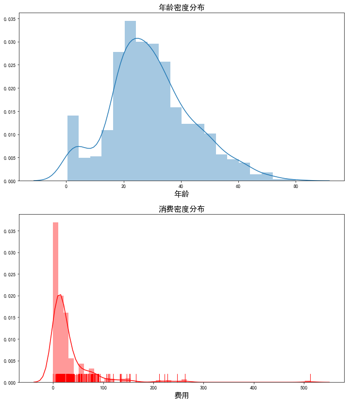

1

1

```
由于补全数据的关系，年龄分布中28岁的比例较高，整体来看，乘客以20-40岁的人为主；在消费方面，中低消费的人群占大多数。
```

由于补全数据的关系，年龄分布中28岁的比例较高，整体来看，乘客以20-40岁的人为主；在消费方面，中低消费的人群占大多数。

1

1

```
sex = ship.groupby(['survived', 'sex']).size()
```

2

```
sex
```

```
survived  sex
0         0       81
          1      468
1         0      233
          1      109
dtype: int64
```

1

1

```
#转换为data.frame
```

2

```
sex = sex.unstack('sex')
```

3

```
sex = sex.rename(index={0:'遇难', 1:'存活'})
```

4

```
sex
```

| sex survived | 0 | 1 |
| --- | --- | --- |
| 遇难 | 81 | 468 |
| 存活 | 233 | 109 |

1

1

```
#计算生存比例
```

2

```
sex_perc = sex/sex.sum() #df可以做数学运算，sex.sum默认求和维度是0
```

3

```
sex_perc
```

| sex survived | 0 | 1 |
| --- | --- | --- |
| 遇难 | 0.257962 | 0.811092 |
| 存活 | 0.742038 | 0.188908 |

1

16

1

```
#绘制性别与死亡率的关系
```

2

```
fig = plt.figure(1, figsize=(7, 7))
```

3

```
ax1 = fig.add_subplot(1, 1, 1)
```

4

```
x = range(2)
```

5

```
a = sex_perc.loc['遇难', :]
```

6

```
b = sex_perc.loc['存活', :]
```

7

```
ax1.bar(x, a, label='遇难', color=sns.color_palette("Set3", 10)[1])
```

8

```
ax1.bar(x, b, bottom=a, label='存活', color=sns.color_palette("Set3", 10)[0])#通过bottom堆积
```

9

```
ax1.set_xticks(range(3)) #将x轴设置成容纳3个维度
```

10

```
ax1.set_xticklabels(['女性', '男性'], fontsize=16)
```

11

```
ax1.set_yticks([])
```

12

```
ax1.legend(['遇难', '存活'],fontsize=16)#按从下到上的顺序命名legend
```

13

```
ax1.set_title('性别生存分布',fontsize=16)
```

14

```
for x,y,z in zip(range(2), a, b):
```

15

```
    ax1.text(x, y/2, '{:.2%}'.format(y), fontsize=16)
```

16

```
    ax1.text(x, y+z/2, '{:.2%}'.format(z), fontsize=16)
```

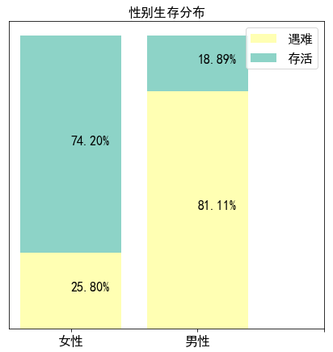

1

1

```
从结果看，女性的死亡率要远低于男性，对于这种二维分类比例的可视化，可以考虑条形堆叠图。以维度较高的轴作为横轴，以维度较低的作为堆叠。
```

从结果看，女性的死亡率要远低于男性，对于这种二维分类比例的可视化，可以考虑条形堆叠图。以维度较高的轴作为横轴，以维度较低的作为堆叠。

1

1

```
女性遇难的比例仅有25.8%， 而男性却高达81.11%，这说明生存率与性别有极大关系，在当时有许多男性选择将生存机会让给女性
```

女性遇难的比例仅有25.8%， 而男性却高达81.11%，这说明生存率与性别有极大关系，在当时有许多男性选择将生存机会让给女性

1

1

```
#绘制pclass与存活率的关系
```

2

```
pclass = ship.groupby(['survived', 'pclass']).size()
```

3

```
pclass
```

```
survived  pclass
0         1          80
          2          97
          3         372
1         1         136
          2          87
          3         119
dtype: int64
```

1

1

```
# pclass.unstack('survived')
```

1

1

```
# pclass.unstack('pclass')
```

2

```
pclass = pclass.unstack()
```

3

```
pclass = pclass.rename(index={0:'遇难', 1:'幸存'})
```

4

```
pclass
```

| pclass survived | 1 | 2 | 3 |
| --- | --- | --- | --- |
| 遇难 | 80 | 97 | 372 |
| 幸存 | 136 | 87 | 119 |

1

1

```
pclass_perc = pclass/pclass.sum()
```

2

```
pclass_perc
```

| pclass survived | 1 | 2 | 3 |
| --- | --- | --- | --- |
| 遇难 | 0.37037 | 0.527174 | 0.757637 |
| 幸存 | 0.62963 | 0.472826 | 0.242363 |

1

16

1

```
a = pclass_perc.loc['遇难', :]
```

2

```
b = pclass_perc.loc['幸存', :]
```

3

```
x = range(3)
```

4

```
fig = plt.figure(figsize=(12, 7))
```

5

```
ax = fig.add_subplot(1, 1, 1)
```

6

```
ax.bar(x, a, label='遇难', color=sns.color_palette('Set3', 10)[3])
```

7

```
ax.bar(x, b, bottom=a, label='幸存', color=sns.color_palette('Set3', 10)[5])
```

8

```
ax.set_xticks(range(4))
```

9

```
ax.set_xticklabels(['一等舱', '二等舱', '三等舱'])
```

10

```
ax.legend(['遇难', '幸存'], fontsize=16)
```

11

```
ax.tick_params(axis='both', labelsize=16)
```

12

```
ax.ticklabel_format
```

13

```
ax.set_yticks([])
```

14

```
for x, y, z in zip(x, a, b):
```

15

```
    ax.text(x, y/2, '{:.2%}'.format(y), fontsize=14)
```

16

```
    ax.text(x, y+z/2, '{:.2%}'.format(z), fontsize=14)
```

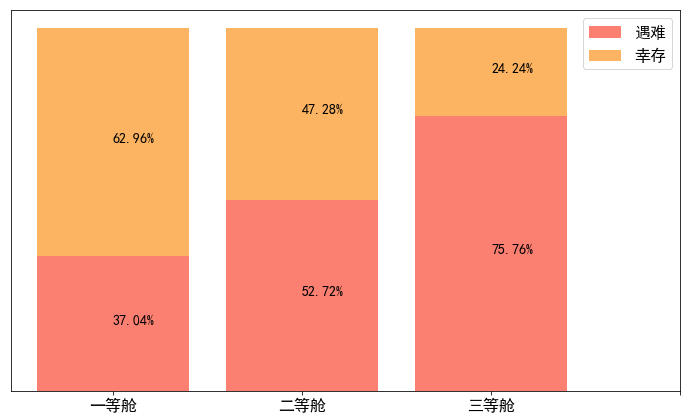

1

1

```
可以看出，三等舱中幸存比例最低，一等舱中幸存比例最高，可以认为pclass是影响存活率的因素之一
```

可以看出，三等舱中幸存比例最低，一等舱中幸存比例最高，可以认为pclass是影响存活率的因素之一

1

17

1

```
fig = plt.figure(figsize=(16, 16))
```

2

3

```
#ax = fig.add_subplot(2, 2, 1)
```

4

```
ax = sns.jointplot('sex', 'survived', data=ship, kind='kde')
```

5

```
plt.title('survived与sex')
```

6

7

```
#ax = fig.add_subplot(2, 2, 2)
```

8

```
ax = sns.jointplot('pclass', 'survived', data=ship, kind='kde')
```

9

```
plt.title('survived与pclass')
```

10

11

```
#ax = fig.add_subplot(2, 2, 3)
```

12

```
ax = sns.jointplot('age', 'survived', data=ship, kind='kde', color='g')
```

13

```
plt.title('survived与age')
```

14

15

```
#ax = fig.add_subplot(2, 2, 4)
```

16

```
ax = sns.jointplot('fare', 'survived', data=ship, kind='kde', color='g', shade=False)
```

17

```
plt.title('survived与fare')
```

```
Text(0.5,1,'survived与fare')
```

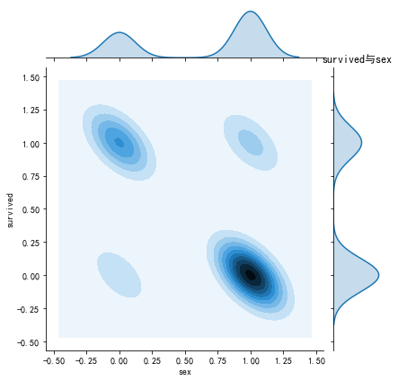

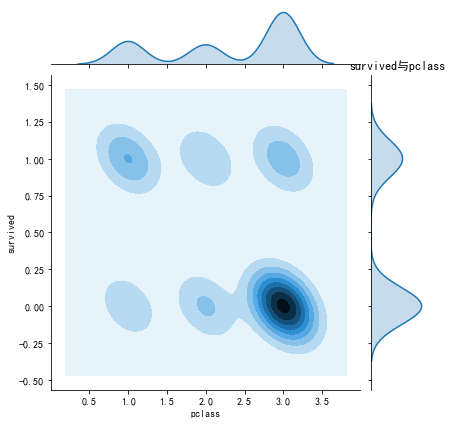

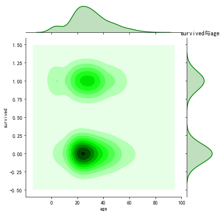

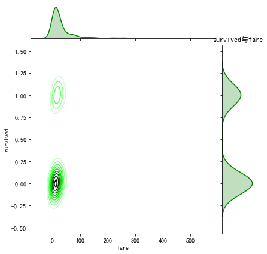

3

1

```
#### 高维特征可视化
```

2

3

```
高维特征作特征之间相关性的探索，原理是将高维特征转化成二维特征的探索，连续变量更适合作为x和y轴，分类变量作为hue参数传入
```

#### 高维特征可视化

高维特征作特征之间相关性的探索，原理是将高维特征转化成二维特征的探索，连续变量更适合作为x和y轴，分类变量作为hue参数传入

1

1

```
sns.pairplot(ship[['age', 'survived', 'pclass', 'sibsp', 'parch']], hue='survived')
```

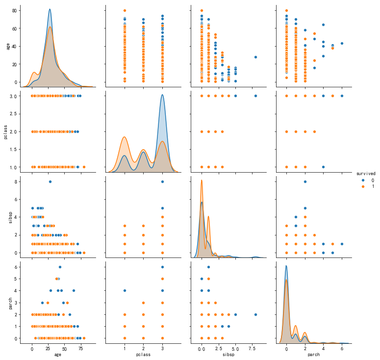

11

1

```
在上图中重点关注对角线上的图片。
```

2

3

[output not shown]

4

5

```
(2, 2)是之前分析过的pclass与存活率的关系
```

6

7

[output not shown]

8

9

[output not shown]

10

11

```
图中还有其他有意思的图像，如（1，3）显示，当同代亲属为3或4个的人，普遍年龄在20岁以内，这些人的死亡率非常高。（1，4）显示，有5个以上非同代亲属的人普遍年纪较大，死亡率也较高。
```

在上图中重点关注对角线上的图片。

(2, 2)是之前分析过的pclass与存活率的关系

图中还有其他有意思的图像，如（1，3）显示，当同代亲属为3或4个的人，普遍年龄在20岁以内，这些人的死亡率非常高。（1，4）显示，有5个以上非同代亲属的人普遍年纪较大，死亡率也较高。

1

1

```
## 统计建模
```

## 统计建模

2

1

```
A = ship
```

2

```
ship.head()
```

|  | survived | pclass | sex | age | sibsp | parch | fare | embark_town | alone |
| --- | --- | --- | --- | --- | --- | --- | --- | --- | --- |
| 0 | 0 | 3 | 1 | 22.0 | 1 | 0 | 7.2500 | Southampton | False |
| 1 | 1 | 1 | 0 | 38.0 | 1 | 0 | 71.2833 | Cherbourg | False |
| 2 | 1 | 3 | 0 | 26.0 | 0 | 0 | 7.9250 | Southampton | True |
| 3 | 1 | 1 | 0 | 35.0 | 1 | 0 | 53.1000 | Southampton | False |
| 4 | 0 | 3 | 1 | 35.0 | 0 | 0 | 8.0500 | Southampton | True |

7

1

```
# 格式化数据
```

2

```
ship.loc[ship.alone == False, 'alone'] = 0
```

3

```
ship.loc[ship.alone == True, 'alone'] = 1
```

4

5

```
ship['age'] = (ship['age'] - ship['age'].min())/(ship['age'].max() - ship['age'].min())
```

6

```
ship['fare'] = (ship['fare'] - ship['fare'].min())/(ship['fare'].max() - ship['fare'].min())
```

7

```
ship['pclass'] = (ship['pclass'] - ship['pclass'].min())/(ship['pclass'].max() - ship['pclass'].min())
```

11

1

```
# 因变量
```

2

```
y = ship['survived']
```

3

```
del ship['survived']
```

4

5

```
# 建立上船位置的哑变量
```

6

```
dumm = pd.get_dummies(ship[['embark_town']])
```

7

```
ship = ship.join(dumm)
```

8

```
del ship['embark_town']
```

9

10

```
# 为避免哑变量之间的完全共线性，删除embark_town_Cherbourg
```

11

```
del ship['embark_town_Cherbourg']
```

1

1

```
ship.head()
```

|  | pclass | sex | age | sibsp | parch | fare | alone | embark_town_Queenstown | embark_town_Southampton |
| --- | --- | --- | --- | --- | --- | --- | --- | --- | --- |
| 0 | 1.0 | 1 | 0.271174 | 1 | 0 | 0.014151 | 0 | 0 | 1 |
| 1 | 0.0 | 0 | 0.472229 | 1 | 0 | 0.139136 | 0 | 0 | 0 |
| 2 | 1.0 | 0 | 0.321438 | 0 | 0 | 0.015469 | 1 | 0 | 1 |
| 3 | 0.0 | 0 | 0.434531 | 1 | 0 | 0.103644 | 0 | 0 | 1 |
| 4 | 1.0 | 1 | 0.434531 | 0 | 0 | 0.015713 | 1 | 0 | 1 |

11

1

```
# 拆分训练集与测试集
```

2

```
from sklearn.cross_validation import train_test_split
```

3

4

```
x_train, x_test, y_train, y_test = train_test_split(ship, y, test_size = 0.3, random_state=1)
```

5

6

```
# 逻辑回归
```

7

```
from sklearn.linear_model import LogisticRegression
```

8

9

```
LR = LogisticRegression()
```

10

11

```
LR.fit(x_train, y_train)
```

```
LogisticRegression(C=1.0, class_weight=None, dual=False, fit_intercept=True,
          intercept_scaling=1, max_iter=100, multi_class='ovr', n_jobs=1,
          penalty='l2', random_state=None, solver='liblinear', tol=0.0001,
          verbose=0, warm_start=False)
```

2

1

```
print('训练集预测结果为：', LR.score(x_train, y_train))
```

2

```
print('测试集预测结果为：', LR.score(x_test, y_test))
```

```
训练集预测结果为： 0.8218298555377207
测试集预测结果为： 0.7723880597014925
```

6

1

```
coef = {}
```

2

```
lrcoef = LR.coef_
```

3

```
index = ship.columns
```

4

```
for i in range(len(index)):
```

5

```
    coef[index[i]] = lrcoef[0, i].round(5)
```

6

```
coef
```

```
{'pclass': -1.72825,
 'sex': -2.41792,
 'age': -1.51948,
 'sibsp': -0.44233,
 'parch': -0.03492,
 'fare': 0.28035,
 'alone': -0.67135,
 'embark_town_Queenstown': 0.21183,
 'embark_town_Southampton': -0.19033}
```

[output not shown]

1

```
采用逻辑回归建模，在训练集模型准确率为82.18%， 测试集准确率为77.24%，预测结果较为不错。
```

2

3

```
具体回归系数来看，
```

4

5

```
pclass:负相关，越靠近底层，存活概率越小；
```

6

7

```
sex:负相关，男性比女性死亡率高；
```

8

9

```
age:负相关，年龄越大存活率越低；
```

10

11

[output not shown]

12

13

```
parch：负相关，系数并不显著，可能非同代亲属数量并不是影响死亡率的主要因素；
```

14

15

```
fare：正相关，这说明社会地位在一定程度上帮助提高了存活率；
```

16

17

```
embark_town:Queenstown系数为正，说明相比于Cherbourg，在该港口上船的人存活率更高；Southampton系数为负，说明相比于Cherbourg，在该港口上船的人存活率更低。
```

采用逻辑回归建模，在训练集模型准确率为82.18%， 测试集准确率为77.24%，预测结果较为不错。

具体回归系数来看，

pclass:负相关，越靠近底层，存活概率越小；

sex:负相关，男性比女性死亡率高；

age:负相关，年龄越大存活率越低；

parch：负相关，系数并不显著，可能非同代亲属数量并不是影响死亡率的主要因素；

fare：正相关，这说明社会地位在一定程度上帮助提高了存活率；

embark_town:Queenstown系数为正，说明相比于Cherbourg，在该港口上船的人存活率更高；Southampton系数为负，说明相比于Cherbourg，在该港口上船的人存活率更低。